# 鲍鱼性别分类——SVM&RF

中央财经大学 王思雨

2018-01-01

# 一、SVM与RF所使用的工具包加载

```r
library(e1071)
library(klaR)           # 导入支持向量机包
library(randomForest)   # 导入随机森林包
library(gbm)
library(RODBC)          # 导入gbm包
library(AppliedPredictiveModeling)
```

# 二、鲍鱼数据读取与预处理

```r
#数据预处理
#数据说明
data(abalone)
head(abalone)              # 获取并载入UCL鲍鱼数据
```

```
##   Type LongestShell Diameter Height WholeWeight ShuckedWeight
## 1    M        0.455    0.365  0.095      0.5140        0.2245
## 2    M        0.350    0.265  0.090      0.2255        0.0995
## 3    F        0.530    0.420  0.135      0.6770        0.2565
## 4    M        0.440    0.365  0.125      0.5160        0.2155
## 5    I        0.330    0.255  0.080      0.2050        0.0895
## 6    I        0.425    0.300  0.095      0.3515        0.1410
##   VisceraWeight ShellWeight Rings
## 1        0.1010       0.150    15
## 2        0.0485       0.070     7
## 3        0.1415       0.210     9
## 4        0.1140       0.155    10
## 5        0.0395       0.055     7
## 6        0.0775       0.120     8
```

```r
str(abalone)
```

```
## 'data.frame':    4177 obs. of  9 variables:
##  $ Type         : Factor w/ 3 levels "F","I","M": 3 3 1 3 2 2 1 1 3 1 ...
##  $ LongestShell : num  0.455 0.35 0.53 0.44 0.33 0.425 0.53 0.545 0.475 0.55 ...
##  $ Diameter     : num  0.365 0.265 0.42 0.365 0.255 0.3 0.415 0.425 0.37 0.44 ...
##  $ Height       : num  0.095 0.09 0.135 0.125 0.08 0.095 0.15 0.125 0.125 0.15 ...
##  $ WholeWeight  : num  0.514 0.226 0.677 0.516 0.205 ...
##  $ ShuckedWeight: num  0.2245 0.0995 0.2565 0.2155 0.0895 ...
##  $ VisceraWeight: num  0.101 0.0485 0.1415 0.114 0.0395 ...
##  $ ShellWeight  : num  0.15 0.07 0.21 0.155 0.055 0.12 0.33 0.26 0.165 0.32 ...
##  $ Rings        : int  15 7 9 10 7 8 20 16 9 19 ...
```

```r
abalone=na.omit(abalone)   # 去除所有缺失值
```

# 三、鲍鱼性别分类——支持向量机SVM

## 3.1 支持向量机模型建立

```r
###第一种格式建立模型
summary(abalone)        # 查看鲍鱼数据总括
```

```
##  Type      LongestShell      Diameter          Height
##  F:1307   Min.   :0.075   Min.   :0.0550   Min.   :0.0000
##  I:1342   1st Qu.:0.450   1st Qu.:0.3500   1st Qu.:0.1150
##  M:1528   Median :0.545   Median :0.4250   Median :0.1400
##           Mean   :0.524   Mean   :0.4079   Mean   :0.1395
##           3rd Qu.:0.615   3rd Qu.:0.4800   3rd Qu.:0.1650
##           Max.   :0.815   Max.   :0.6500   Max.   :1.1300
##   WholeWeight     ShuckedWeight    VisceraWeight     ShellWeight
##  Min.   :0.0020   Min.   :0.0010   Min.   :0.0005   Min.   :0.0015
##  1st Qu.:0.4415   1st Qu.:0.1860   1st Qu.:0.0935   1st Qu.:0.1300
##  Median :0.7995   Median :0.3360   Median :0.1710   Median :0.2340
##  Mean   :0.8287   Mean   :0.3594   Mean   :0.1806   Mean   :0.2388
##  3rd Qu.:1.1530   3rd Qu.:0.5020   3rd Qu.:0.2530   3rd Qu.:0.3290
##  Max.   :2.8255   Max.   :1.4880   Max.   :0.7600   Max.   :1.0050
##      Rings
##  Min.   : 1.000
##  1st Qu.: 8.000
##  Median : 9.000
##  Mean   : 9.934
##  3rd Qu.:11.000
##  Max.   :29.000
```

```r
model=svm(Type~.,data=abalone)  # 利用第一种形式建模
###第二种格式建立模型
x=abalone[,-1]  # 提取abalone数据中除第1列以外的数据作为特征变量
y=abalone[,1]     # 提取abalone数据中的第1列数据作为监督的分类变量
model=svm(x,y,kernel ="radial",gamma =if(is.vector(x)) 1 else 1/ncol(x))  # 利用高斯核函数进行建模
summary(model)
```

```
##
## Call:
## svm.default(x = x, y = y, kernel = "radial", gamma = if (is.vector(x)) 1 else 1/ncol(x))
##
##
## Parameters:
##    SVM-Type:  C-classification
##  SVM-Kernel:  radial
##        cost:  1
##       gamma:  0.125
##
## Number of Support Vectors:  3400
##
##  ( 1451 1285 664 )
##
##
## Number of Classes:  3
##
## Levels:
##  F I M
```

## 3.2 鲍鱼数据SVM模型模式选择

```r
attach(abalone)     # 将数据abalone按列单独确认为向量
x=subset(abalone,select=-Type) # 确定特征变量为abalone中除去Type的其他项
y=Type      # 确定结果变量为数据iris中的Species项
type=c("C-classification","nu-classification")  # 分类方式
kernel=c("linear","polynomial","radial","sigmoid")
pred=array(0,dim=c(4177,2,4)) #初始化预测结果矩阵的三维长度150，2，4
err=matrix(0,2,4)   #初始化模型错误矩阵的两维分别为2，4
yy=as.integer(y)    #为方便模型精度计算，将结果变量数量化为1,2,3
```

$~~~~~~~$可以从模型比较结果中看到，利用测试数据集在模型中使用高斯核radial以及利用nu-classification分类的测试集的分类泛化误差最小，所以在鲍鱼数据集中的SVM模型建立中使用这种模型进行分析。

```r
for(i in 1:2)           #确认i影响的维度代表分类方式
{
  for(j in 1:4) #确认j影响的维度代表核函数
  {
    pred[,i,j]=predict(svm(x,y,type=type[i],kernel=kernel[j]),x)
    err[i,j]=sum(pred[,i,j]!=yy)
  }
}
dimnames(err)=list(type,kernel)#确定模型精度变量的列名和行名
err                   # 在此模型中利用高斯核和nu-classification分类效果最好，查询分类名称
```

```
##                   linear polynomial radial sigmoid
## C-classification    1845       1998   1768    2203
## nu-classification   1933       1841   1598    2062
```

```r
table(pred[,2,3],y)     # 模型预测精度展示，改正行名
```

```
##    y
##        F    I    M
##   1  718  107  390
##   2  213 1067  344
##   3  376  168  794
```

```r
                      # 展示混淆矩阵。进行可视化
                      # 计算错误分类率
```

## 3.3 鲍鱼数据SVM模型可视化结果

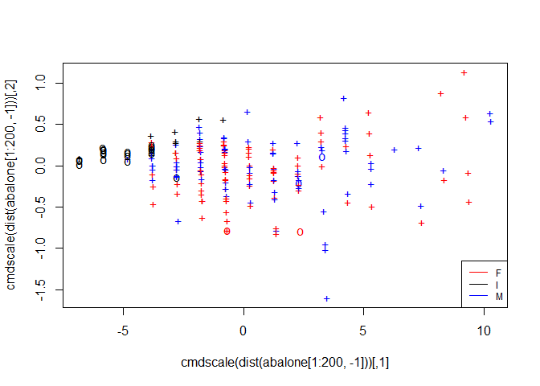

```r
###模型可视化
plot(cmdscale(dist(abalone[1:200,-1])),col=c("red","black", "blue")[as.integer(abalone[,1])],pch= c("o","+")[1:200 %in% model$index + 1])
# 绘制模型分类散点图，利用dist函数计算前200个样本的样本间欧氏距离(euclidean)，利用多维标度法将高维数据降低到2维方便可视化
legend("bottomright",-0.5,c("F","I","M"),col=c("red","black","blue"),
       cex=0.75,lty=1)
```

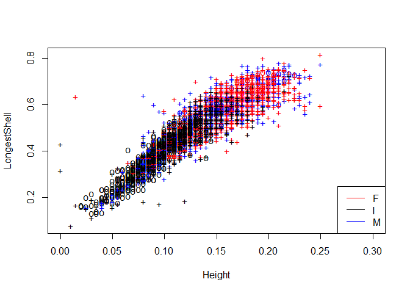

```r
data(abalone)
model=svm(Type~., data = abalone)
plot(model,abalone,LongestShell~Height,fill=FALSE,symbolPalette=c("red","black","blue"),svSymbol="+",xlim=c(0,0.3))
# 绘制支持向量机模型类别关于LongestShell长度和Height重量的分类情况,利用两个向量分类效果并不怎么好
legend("bottomright",c("F","I","M"), col=c("red","black","blue"), lty=1)  # 标签类型选择直线
```

## 3.4 鲍鱼数据SVM模型变量权重优化

```r
###模型进一步优化，设置权重比重
wts=c(1,1,1)        # 确定模型各个类别的比重为1：1：1
names(wts)=c("F","I","M")   #确定各个比重对应的类别
model1=svm(x,y,class.weights=wts)
pred1=predict(model1,x)
table(pred1,y)      #显示混淆矩阵
```

```
##      y
## pred1    F    I    M
##     F  354   34  240
##     I  180 1075  308
##     M  773  233  980
```

```r
                  #展示混淆矩阵图形
                  #计算每一类别的错分率

wts=c(5,1,5)  # 由于F和M的错分比重较大，所以将模型各个类别的比重更改为5：1：5，
names(wts)=c("F","I","M")   #确定各个比重对应的类别
model2=svm(x,y,class.weights=wts)
pred2=predict(model2,x)
table(pred2,y)      #显示混淆矩阵，错分更大
```

```
##      y
## pred2    F    I    M
##     F  421   63  266
##     I   13  528   43
##     M  873  751 1219
```

```r
                  #可视化混淆矩阵
                  #计算每一个类别的错分率

wts=c(5,3,5)    # 进行再次进行优化，三种比重都进行调整，使不易分错的M的权重减小
names(wts)=c("F","I","M")
model3=svm(x,y,class.weights=wts)
pred3=predict(model3,x)
table(pred3,y)
```

```
##      y
## pred3    F    I    M
##     F  421   61  266
##     I   88  940  169
##     M  798  341 1093
```

# 四、鲍鱼性别分类——随机森林RF

## 4.1 鲍鱼数据展示与预处理

$~~~~~~~$将鲍鱼数据进行查看，并将Type性别分类数据进行因子化，使得随机森林模型可以识别，并且划分以70%和30%的比例形成测试集和训练集。

```r
head(abalone)                             #查看鲍鱼数据变量
```

```
##   Type LongestShell Diameter Height WholeWeight ShuckedWeight
## 1    M        0.455    0.365  0.095      0.5140        0.2245
## 2    M        0.350    0.265  0.090      0.2255        0.0995
## 3    F        0.530    0.420  0.135      0.6770        0.2565
## 4    M        0.440    0.365  0.125      0.5160        0.2155
## 5    I        0.330    0.255  0.080      0.2050        0.0895
## 6    I        0.425    0.300  0.095      0.3515        0.1410
##   VisceraWeight ShellWeight Rings
## 1        0.1010       0.150    15
## 2        0.0485       0.070     7
## 3        0.1415       0.210     9
## 4        0.1140       0.155    10
## 5        0.0395       0.055     7
## 6        0.0775       0.120     8
```

```r
dim(abalone)                              #观察维度
```

```
## [1] 4177    9
```

```r
#将变量Type性别转化为因子型变量，以便进行随机森林的构建
abalone$Type=as.factor(abalone$Type)
#将数据分为训练集和测试集,按照数据集的70%划分为训练数据，30%为测试数据作为样本划分标准
set.seed(100)
train=abalone[sample(1:dim(abalone)[1],ceiling(dim(abalone)[1]*0.7)),]
test=abalone[-sample(1:dim(abalone)[1],ceiling(dim(abalone)[1]*0.7)),]
```

## 4.2 构建随机森林模型评价函数

```r
#定义随机森林模型测试集结果评价函数，
#包含Accuracy，recall，precision，F_measure四个评价指标
#Accuracy总正确率，recall后验准确率，precision先验准确率
index2=function(table) {
  Accuracy=table[1,1]+table[2,2]+table[3,3]
  precision=table[2,2]/sum(table[,2])
  recall=table[2,2]/sum(table[2,])
  F_measure=2*precision*recall/(precision+recall)#计算Recall，Precision和F-measure
  results=data.frame(Accuracy=Accuracy,recall=recall,precision=precision,F_measure=F_measure)
  return(results)
}
```